# Heart Disease Analysis

Ankita Pal

15th August, 2020

### *Introduction :-*

Heart disease describes a range of conditions that affect your heart. The term “heart disease” is often used interchangeably with the term “cardiovascular disease”. Cardiovascular disease generally refers to conditions that involve narrowed or blocked blood vessels that can lead to a heart attack, chest pain (angina) or stroke.  
Heart disease is one of the biggest causes of morbidity and mortality among the population of the world. Prediction of cardiovascular disease is regarded as one of the most important subjects in the section of clinical data analysis.  
Machine learning (ML) proves to be effective in assisting in making decisions and predictions from the large quantity of data produced by the healthcare industry.  
In this short project, I will be applying Machine Learning approaches(and eventually comparing them) for classifying whether a person is suffering from heart disease or not, using one of the most used dataset — [Cleveland Heart Disease dataset](https://archive.ics.uci.edu/ml/datasets/Heart+Disease) from the [UCI Repository](https://archive.ics.uci.edu/ml/index.php).

### *The Data :-*

Here I have used the Cleveland Heart Disease dataset from the UCI Repository.

Cleveland Heart Disease Data

| age | sex | cp | trestbps | chol | fbs | restecg | thalach | exang | oldpeak | slope | ca | thal | target |
| --- | --- | --- | --- | --- | --- | --- | --- | --- | --- | --- | --- | --- | --- |
| 63 | 1 | 3 | 145 | 233 | 1 | 0 | 150 | 0 | 2.3 | 0 | 0 | 1 | 1 |
| 37 | 1 | 2 | 130 | 250 | 0 | 1 | 187 | 0 | 3.5 | 0 | 0 | 2 | 1 |
| 41 | 0 | 1 | 130 | 204 | 0 | 0 | 172 | 0 | 1.4 | 2 | 0 | 2 | 1 |
| 56 | 1 | 1 | 120 | 236 | 0 | 1 | 178 | 0 | 0.8 | 2 | 0 | 2 | 1 |
| 57 | 0 | 0 | 120 | 354 | 0 | 1 | 163 | 1 | 0.6 | 2 | 0 | 2 | 1 |
| 57 | 1 | 0 | 140 | 192 | 0 | 1 | 148 | 0 | 0.4 | 1 | 0 | 1 | 1 |

### *Objectives :-*

Here I am concentrating on the following two objectives:  
Q1. How being affected by heart disease is related to the features (categorical) of a person?  
Q2. Find a model to predict heart disease of a patient given the features.

### *The Approach :-*

The code is implemented in R and different classification models were applied. In this analysis I will be using the following classification models and comparing them.

- Logistic Regression
- k-Nearest Neighbors
- Random Forest

### *Data Analysis for Objective 1 :-*

Let us first perform the basic analysis for the first objective and conclude how the features are related to being affected by heart disease. The required data processing have been done as follows. I have checked whether there are any missing values in the data, but the data has no missing values. Then, the identified categorical variables have been converted to factors.

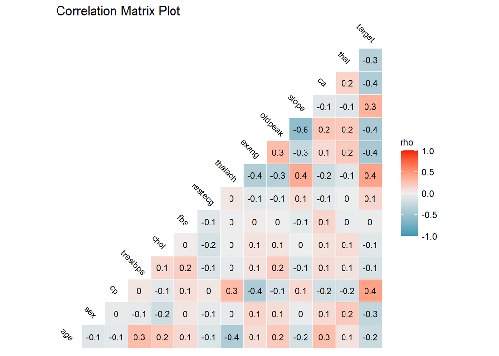

Checking the effect of Categorical variables on being effected by heart disease.

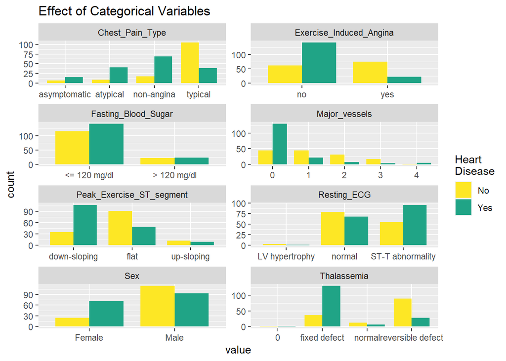

From the above plot I have made some brief conclusions:

- In **Chest Pain Type**, non-angina type of chest pain has greater risk of being affected.
- If a person does not have **Exercise Induced Angina**, then he/she will have greater risk of being affected.
- If **Fasting Blood Sugar** is $<=120$ mg/dl, then he/she has greater risk of being affected.
- If there is 0 number of **Major Vessels**, then there is greater risk of being affected.
- If **Peak Exercise ST segment** has downward slope then there is greater risk of being affected.
- If **Resting ECG** pattern has ST-T abnormality, then there is greater chance of being affected.
- In case of **Sex**, Females get more affected by heart disease than Males.
- If there is fixed defect of **Thalassemia** then there is high chance of getting affected.

### *Data Analysis for Objective 2 :-*

For the second objective, the first step is to divide the data into training and testing data sets. In this project, I have divided the data into an 80: 20 ratio. That is, the training size is 80% and testing size is 20% of the whole data.  
For each of the approaches I have produced Confusion Matrix, which displays the correctly predicted as well as incorrectly predicted values by a classifier.

**Logistic Regression**

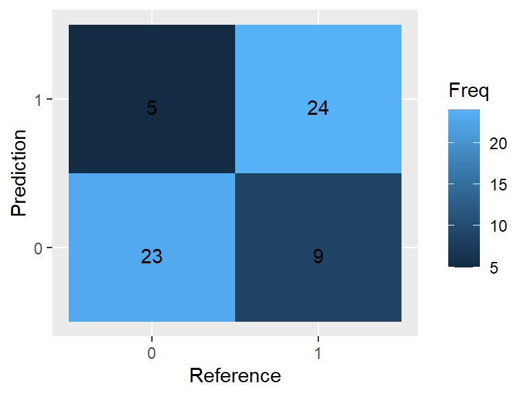

The Accuracy of correct predictions of Logistic regression in the testing set is 77.05%.  
Let us see at all the confusion matrices for each classifier, and then draw conclusion from them.

**k - Nearest Neighbors**

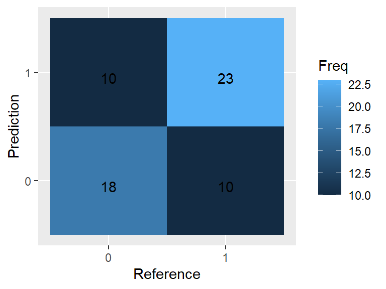

The Accuracy of correct predictions of k-Nearest Neighbors in the testing set is 67.21%.

**Random Forest**

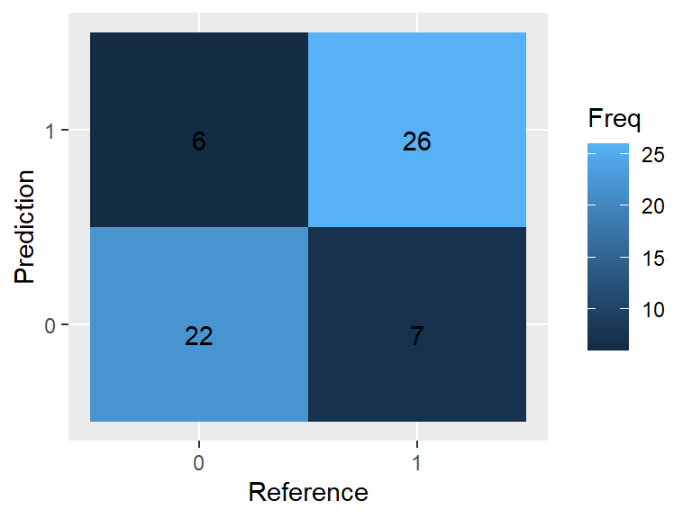

The Accuracy of correct predictions of Random Forest in the testing set is 78.69%.  
Now lets sum up our above analysis in a table, so that I can conclude the best fit model. The following table consists of 3 rows and 2 columns. The rows contains the names of the approaches used for analysis and the columns include the values of overall accuracy and $F_1$ score. The $F_1$ score is computed from the Confusion Matrix, and can be interpreted as the value tends to 1 we can say that the fit is good and the fit will not be good if the value tends to 0.

|  | Accuracy | F1 Score |
| --- | --- | --- |
| Logistic Regression | 77.04918 | 0.7666667 |
| k-NN | 67.21311 | 0.6428571 |
| Random Forest | 78.68852 | 0.7719298 |

From the above table, I was able to conclude that for both Logistic Regression and Random Forest the overall Accuracy has negligible difference and also the $F_1$ score is approximately the same.

### *Conclusion :-*

So, from this analysis I would like to conclude that for predicting Heart Disease given the information in the above data, we can either use Logistic Regression model or Random Forest model.